# Data Science Project

SAIDEEP REDDY THADURU

07/11/24

# Answers

## Part 1

**Question 1:**

- Offensive: 56.3% eFG
- Defensive: 47.9% eFG

**Question 2:** 81.6%

**Question 3:** 46.2%

**Question 4:** This is a written question. Please leave your response in the document under Question 5.

**Question 6:**

- Round 1: 83.3%
- Round 2: 58.3%
- Conference Finals: 55.6%
- Finals: 66.7%

**Question 7:**

- Percent of +5.0 net rating teams making the 2nd round next year: 61.8%
- Percent of top 5 minutes played players who played in those 2nd round series: 51.0%

# Setup and Data

```r
player_data <- read_csv("C:/Users/ompra/OneDrive/Documents/NBA  Playoff Perfomance/player_game_data.csv")
team_game_data <- read_csv("C:/Users/ompra/OneDrive/Documents/NBA  Playoff Perfomance/team_game_data.csv")
```

## Part 1 – Data Cleaning

In this section, you’re going to work to answer questions using data from both team and player stats. All provided stats are on the game level.

### Question 1

**QUESTION:** What was the Warriors’ Team offensive and defensive eFG% in the 2015-16 regular season? Remember that this is in the data as the 2015 season.

```r
# Filtering the data for GSW 2015 Regular season and checking for non-empty fields
warriors_2015_data <- team_game_data %>%filter(off_team == 'GSW', season == 2015, gametype == 2) %>%filter(!is.na(fgmade) & !is.na(fg3made) & !is.na(fgattempted))

# filtering the  warriors 2015 regular season defensive data
warriors_def_2015_data <- team_game_data %>%
 filter(def_team == 'GSW', season == 2015, gametype == 2) %>%
 filter(!is.na(fgmade) & !is.na(fg3made) & !is.na(fgattempted))

# offensive eFG% calculation
offensive_fg <- sum(warriors_2015_data$fgmade)
offensive_3p <- sum(warriors_2015_data$fg3made)
offensive_fga <- sum(warriors_2015_data$fgattempted)
offensive_efg_percentage <- (offensive_fg + 0.5 * offensive_3p) / offensive_fga

# Calculate defensive eFG%
defensive_fg <- sum(warriors_def_2015_data$fgmade)
defensive_3p <- sum(warriors_def_2015_data$fg3made)
defensive_fga <- sum(warriors_def_2015_data$fgattempted)
defensive_efg_percentage <- (defensive_fg + 0.5 * defensive_3p) / defensive_fga

cat("Offensive", offensive_efg_percentage * 100, "%eFG\n")
```

```
## Offensive 56.29718 %eFG
```

```r
cat("defensive", defensive_efg_percentage * 100, "%eFG\n")
```

```
## defensive 47.86465 %eFG
```

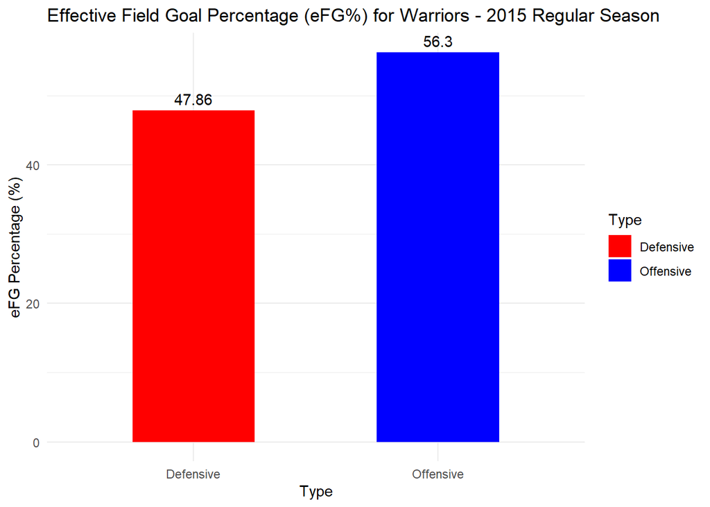

```r
library(dplyr)
library(ggplot2)
efg_data <- data.frame(
  Type = c("Offensive", "Defensive"),
  eFG_Percentage = c(offensive_efg_percentage * 100, defensive_efg_percentage * 100)
)
# Plotting the eFG%
ggplot(efg_data, aes(x = Type, y = eFG_Percentage, fill = Type)) +
  geom_bar(stat = "identity", width = 0.5) +
  geom_text(aes(label = round(eFG_Percentage, 2)), vjust = -0.5) +
  labs(title = "Effective Field Goal Percentage (eFG%) for Warriors - 2015 Regular Season",
       x = "Type",
       y = "eFG Percentage (%)") +
  theme_minimal() +
  scale_fill_manual(values = c("Offensive" = "blue", "Defensive" = "red"))
```

**ANSWER 1:**

Offensive: 56.3% eFG  
Defensive: 47.9% eFG

### Question 2

**QUESTION:** What percent of the time does the team with the higher eFG% in a given game win that game? Use games from the 2014-2023 regular seasons. If the two teams have an exactly equal eFG%, remove that game from the calculation.

```r
# regular seasons data between 2014 and 2023
regular_seasons_data <- team_game_data %>%
  filter(season >= 2014 & season <= 2023 & gametype == 2)

# effective field goal percentage (eFG%)
regular_seasons_data <- regular_seasons_data %>%
  mutate(eFG_percent = (fgmade + 0.5 * fg3made) / fgattempted)

# Group by game ID and the difference in eFG% for each game
game_groups <- regular_seasons_data %>%
  group_by(nbagameid) %>%
  summarise(
    team1_eFG = first(eFG_percent),
    team2_eFG = last(eFG_percent),
    team1_win = first(off_win)
  ) %>%
  filter(team1_eFG != team2_eFG)

# percentage of games won by the team with the higher eFG%
higher_eFG_win_percentage <- game_groups %>%
  mutate(higher_eFG_win = (team1_eFG > team2_eFG & team1_win == 1) | (team2_eFG > team1_eFG & team1_win == 0)) %>%
  summarise(percentage = mean(higher_eFG_win) * 100) %>%
  pull(percentage)

higher_eFG_win_percentage
```

```
## [1] 81.60141
```

```r
head(higher_eFG_win_percentage)
```

```
## [1] 81.60141
```

**ANSWER 2:**

81.6%

### Question 3

**QUESTION:** What percent of the time does the team with more offensive rebounds in a given game win that game? Use games from the 2014-2023 regular seasons. If the two teams have an exactly equal number of offensive rebounds, remove that game from the calculation.

```r
# data for regular seasons between 2014 and 2023
regular_data <- team_game_data %>%
  filter(season >= 2014 & season <= 2023 & gametype == 2)

# Grouping by game ID
game_groups_rebounds <- regular_data %>%
  group_by(nbagameid) %>%
  summarise(
    team1_off_rebounds = first(reboffensive),
    team2_off_rebounds = last(reboffensive),
    team1_win = first(off_win)
  ) %>%
  filter(team1_off_rebounds != team2_off_rebounds)

# percentage of games won by the team with more offensive rebounds calculation
higher_off_rebounds_win_percentage <- game_groups_rebounds %>%
  mutate(higher_off_rebounds_win = (team1_off_rebounds > team2_off_rebounds &    team1_win == 1) | (team2_off_rebounds > team1_off_rebounds & team1_win == 0)) %>%
  summarise(percentage = mean(higher_off_rebounds_win) * 100) %>%
  pull(percentage)

higher_off_rebounds_win_percentage
```

```
## [1] 46.21415
```

**ANSWER 3:**

46.2%

### Question 4

**QUESTION:** Do you have any theories as to why the answer to question 3 is lower than the answer to question 2? Try to be clear and concise with your answer.

**ANSWER 4:**

The percentage of games won by the team with more offensive rebounds is lower than that won by the team with a higher effective field goal percentage (eFG%) because eFG% directly reflects shooting efficiency, which has a more immediate and significant impact on scoring and winning games. Effective field goal percentage accounts for both two-point and three-point shots, indicating how well a team converts its shot attempts into points. In contrast, while offensive rebounds provide additional scoring opportunities by retaining possession, they do not guarantee that these opportunities are converted into points efficiently. A team can have many offensive rebounds but still struggle with poor shooting accuracy. Therefore, shooting efficiency (eFG%) is a more reliable and direct indicator of game success compared to the extra possessions provided by offensive rebounds, leading to a higher win percentage for teams with higher eFG%.

### Question 5

**QUESTION:** Look at players who played at least 25% of their possible games in a season and scored at least 25 points per game played. Of those player-seasons, what percent of games were they available for on average? Use games from the 2014-2023 regular seasons.

For example:

- Ja Morant does not count in the 2023-24 season, as he played just 9 out of 82 games this year, even though he scored 25.1 points per game.
- Chet Holmgren does not count in the 2023-24 season, as he played all 82 games this year but scored 16.5 points per game.
- LeBron James does count in the 2023-24 season, as he played 71 games and scored 25.7 points per game.

```r
# regular season data from 2014-2023
reg_season_data <- player_data %>%
  filter(gametype == 2, season >= 2014, season <= 2023)

# number of games each player played in each season calculation
player_season_games <- reg_season_data %>%
  group_by(season, nbapersonid, player_name) %>%
  summarise(games_played = n_distinct(nbagameid), .groups = 'drop')

player_season_points <- reg_season_data %>%
  group_by(season, nbapersonid, player_name) %>%
  summarise( total_points = sum((fg2made * 2) + (fg3made * 3) + fgmade, na.rm =  TRUE),.groups = 'drop')



# Merging the games played and total points dataframes
player_season_stats <- left_join(player_season_games, player_season_points, by = c("season", "nbapersonid", "player_name"))

# Calculating points per game
player_season_stats <- player_season_stats %>%
  mutate(points_per_game = total_points / games_played)

# Defining the total number of games in a regular season (82 games) as they were 72 during covid seasons
player_season_stats <- player_season_stats %>%
  mutate(total_regular_season_games = ifelse(season %in% c(2019, 2020), 72, 82))

# Calculating the percentage of games played in each season
player_season_stats <- player_season_stats %>%
  mutate(percent_games_played = (games_played / total_regular_season_games) * 100)

#players who played at least 25% of their possible games and scored at least 25 points per game
filtered_player_season_stats <- player_season_stats %>%
  filter(percent_games_played >= 25, points_per_game >= 25)

# Calculating the average percent of games played for the filtered players
average_percent_games_played <- filtered_player_season_stats %>%
  summarise(avg_percent_games_played = mean(percent_games_played, na.rm = TRUE)) %>%pull(avg_percent_games_played)

cat("Answer:", round(average_percent_games_played, 1), "% games")
```

```
## Answer: 99.8 % games
```

```r
# Print the result
print(average_percent_games_played)
```

```
## [1] 99.79847
```

## Question 6

**QUESTION:** What % of playoff series are won by the team with home court advantage? Give your answer by round. Use playoffs series from the 2014-**2022** seasons. Remember that the 2023 playoffs took place during the 2022 season (i.e. 2022-23 season).

**ANSWER 6:**

```r
library(tidyverse)
library(readr)
library(dplyr)
# Load data
data <- read_csv("C:/Users/ompra/OneDrive/Documents/NBA  Playoff Perfomance/team_game_data.csv")
```

```r
# playoffs data between 2014-2022
playoff_data <- data %>%
  filter(season %in% 2014:2022, gametype == 4)
  playoff_data <- playoff_data %>%
  group_by(nbagameid) %>%
  slice(n()) %>%
  ungroup()

 #function to determine the round from game_id
get_round <- function(game_id) {
  game_number <- as.numeric(str_sub(as.character(game_id), -3))
  if (game_number < 200) {
    return('Round 1')
  } else if (game_number >= 200 & game_number < 300) {
    return('Round 2')
  } else if (game_number >= 300 & game_number < 400) {
    return('Conference Finals')
  } else {
    return('Finals')
  }
}

# Applying the function to determine the round
playoff_data <- playoff_data %>%
  mutate(round = map_chr(nbagameid, get_round))
playoff_data <- playoff_data %>%
  mutate(
    series_id = pmap_chr(list(season, round, offensivenbateamid, defensivenbateamid),
                         ~ paste0(sort(c(..3, ..4)), collapse = '-'))
  )

# Ensuring series_id reflects the correct series by sorting team IDs
playoff_data <- playoff_data %>%
  mutate(series_id = str_c(season, '-', round, '-', series_id))
# Determining the first game of each series and the home team
first_games <- playoff_data %>%
  group_by(series_id) %>%
  arrange(gamedate) %>%  # Ensuring the data is ordered by date
  slice(1) %>%  # Selecting the first game for each series
  ungroup() %>%
  mutate(home_court_advantage = off_home)  # Adding home court advantage column where 1 indicates home advantage

series_outcomes <- playoff_data %>%
  group_by(series_id) %>%
  summarise(
    off_team_wins = sum(off_win),
    def_team_wins = sum(def_win),
    .groups = 'drop'
  ) %>%
  left_join(first_games, by = "series_id") %>%
  mutate(
    series_winner = if_else(off_team_wins > def_team_wins, offensivenbateamid, defensivenbateamid),
    home_court_winner = if_else(
      (series_winner == offensivenbateamid & off_home == 1) |  # offensive team wins and had home court advantage
      (series_winner == defensivenbateamid & off_home == 0),   # defensive team wins and offensive team did not have home court
      1,
      0
    )
  )

# checking if the series winner had home-court advantage
final_results <- series_outcomes %>%
  mutate(
    # Checkinf if the series winner had home court advantage in the first game
    home_court_advantage_winner = if_else(
      (series_winner == offensivenbateamid & off_home == 1) | # offensive team wins and had home court
      (series_winner == defensivenbateamid & off_home == 0),  # defensive team wins and offensive did not have home court
      1,
      0
    )
  )


winning_percentage_by_round <- final_results %>%
  group_by(round) %>%
  summarise(
    total_series = n(),  # Total series in each round
    won_by_home_advantage = sum(home_court_advantage_winner, na.rm = TRUE),  # Sum up all 1s in the home_court_advantage_winner
    winning_percentage = won_by_home_advantage / total_series * 100  #  percentage
  ) %>%
  ungroup()  # Removing the grouping structure for further use



# results in a formatted manner
winning_percentage_by_round %>%
  mutate(print_statement = paste(round, ": ", format(winning_percentage, nsmall = 1), "%", sep = "")) %>%
  pull(print_statement) %>%
  walk(print)
```

```
## [1] "Conference Finals: 55.55556%"
## [1] "Finals: 66.66667%"
## [1] "Round 1: 83.33333%"
## [1] "Round 2: 58.33333%"
```

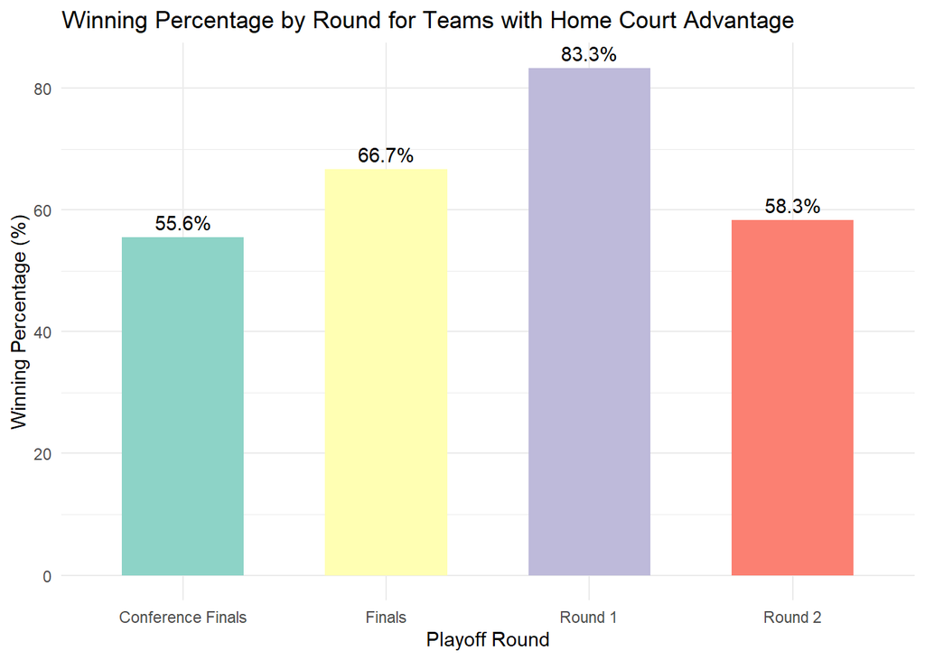

```r
# Plotting the results
ggplot(winning_percentage_by_round, aes(x = round, y = winning_percentage, fill = round)) +
  geom_bar(stat = "identity", width = 0.6) +
  geom_text(aes(label = paste0(round(winning_percentage, 1), "%")), vjust = -0.5) +
  labs(title = "Winning Percentage by Round for Teams with Home Court Advantage",
       x = "Playoff Round",
       y = "Winning Percentage (%)") +
  theme_minimal() +
  scale_fill_brewer(palette = "Set3") +
  theme(legend.position = "none")
```

Round 1: 83.3%  
Round 2: 58.3%  
Conference Finals: 55.6%  
Finals: 66.7%

## Question 7

**QUESTION:** Among teams that had at least a +5.0 net rating in the regular season, what percent of them made the second round of the playoffs the **following** year? Among those teams, what percent of their top 5 total minutes played players (regular season) in the +5.0 net rating season played in that 2nd round playoffs series? Use the 2014-2021 regular seasons to determine the +5 teams and the 2015-2022 seasons of playoffs data.

For example, the Thunder had a better than +5 net rating in the 2023 season. If we make the 2nd round of the playoffs **next** season (2024-25), we would qualify for this question. Our top 5 minutes played players this season were Shai Gilgeous-Alexander, Chet Holmgren, Luguentz Dort, Jalen Williams, and Josh Giddey. If three of them play in a hypothetical 2nd round series next season, it would count as 3/5 for this question.

*Hint: The definition for net rating is in the data dictionary.*

```r
library(tidyverse)
library(readr)

# team game data
nba_team_data <- read_csv("C:/Users/ompra/OneDrive/Documents/NBA  Playoff Perfomance/team_game_data.csv")
# player game data
nba_player_data <- read_csv("C:/Users/ompra/OneDrive/Documents/NBA  Playoff Perfomance/player_game_data.csv")
# Calculating net ratings for regular seasons 2014-2021
seasonal_team_data <- nba_team_data %>%
  filter(gametype == 2, season >= 2014, season <= 2021) %>%
  select(nbagameid, season, off_team_name, defensivenbateamid, points, possessions) %>%
  left_join(nba_team_data %>%
              select(nbagameid, offensivenbateamid, points) %>%
              rename(opponent_points = points, opponent_team_id = offensivenbateamid),
            by = c("nbagameid", "defensivenbateamid" = "opponent_team_id")) %>%
  group_by(season, off_team_name) %>%
  summarise(
    total_points = sum(points),
    total_points_allowed = sum(opponent_points),
    total_possessions = sum(possessions),
    .groups = 'drop'
  ) %>%
  mutate(net_rating = (total_points - total_points_allowed) / total_possessions * 100)

# Filter teams with net rating >= 5.0
teams_plus_5 <- seasonal_team_data %>%
  filter(net_rating >= 5.0)

# playoff performance for 2015-2022

playoff_stats <- nba_team_data %>%
  filter(gametype == 4, season >= 2015, season <= 2022) %>%
  group_by(season, off_team_name) %>%
  summarise(games_played = n_distinct(nbagameid), .groups = 'drop') %>%
  filter(games_played >7) %>%
  mutate(previous_season = season-1)
print(colnames(playoff_stats))
```

```
## [1] "season"          "off_team_name"   "games_played"    "previous_season"
```

```r
second_round_teams <- teams_plus_5 %>%
  inner_join(playoff_stats, by = c("season" = "previous_season", "off_team_name"))



# The percentage of +5.0 net rating teams that made the second round
percent_second_round <- nrow(second_round_teams) / nrow(teams_plus_5) * 100



# Filtering for regular season games and then finding the top 5 players by total minutes played
top_5_players <- nba_player_data %>%
  filter(
    team_name %in% second_round_teams$off_team_name,  # Filteingr for teams that made it to the second round
    season %in% second_round_teams$season,
    gametype == 2  # Ensuring only regular season data is considered
  ) %>%
  group_by(season, team_name) %>%
  top_n(5, wt = seconds) %>%  # Selecting top 5 players by total playing time
  ungroup()

second_round_teams <- second_round_teams %>%
  rename(playoff_season = season.y)
second_round_teams
```

```
## # A tibble: 21 × 8
##    season off_team_name      total_points total_points_allowed total_possessions
##     <dbl> <chr>                     <dbl>                <dbl>             <dbl>
##  1   2014 Atlanta Hawks              8409                 7964              7710
##  2   2014 Golden State Warr…         9016                 8188              8081
##  3   2014 San Antonio Spurs          8461                 7953              7798
##  4   2015 Cleveland Cavalie…         8555                 8063              7723
##  5   2015 Golden State Warr…         9421                 8539              8265
##  6   2015 San Antonio Spurs          8490                 7618              7733
##  7   2016 Golden State Warr…         9503                 8549              8214
##  8   2016 Houston Rockets            9458                 8985              8219
##  9   2017 Golden State Warr…         9304                 8813              8167
## 10   2017 Houston Rockets            9212                 8517              7989
## # ℹ 11 more rows
## # ℹ 3 more variables: net_rating <dbl>, playoff_season <dbl>,
## #   games_played <int>
```

```r
playoff_entry <- nba_player_data %>%
  filter(gametype == 4)
number_of_rows <- nrow(playoff_entry)
print(playoff_entry)
```

```
## # A tibble: 46,986 × 59
##    nbagameid gamedate   season gametype nbapersonid player_name  nbateamid team
##        <dbl> <date>      <dbl>    <dbl>       <dbl> <chr>            <dbl> <chr>
##  1  40700174 2008-04-26   2007        4        1905 Andrei Kiri…    1.61e9 UTA
##  2  40700174 2008-04-26   2007        4        2430 Carlos Booz…    1.61e9 UTA
##  3  40700174 2008-04-26   2007        4        2246 Mehmet Okur     1.61e9 UTA
##  4  40700174 2008-04-26   2007        4      200758 Ronnie Brew…    1.61e9 UTA
##  5  40700174 2008-04-26   2007        4      101114 Deron Willi…    1.61e9 UTA
##  6  40700174 2008-04-26   2007        4        1723 Matt Harpri…    1.61e9 UTA
##  7  40700174 2008-04-26   2007        4      200794 Paul Millsap    1.61e9 UTA
##  8  40700174 2008-04-26   2007        4      101179 Ronnie Price    1.61e9 UTA
##  9  40700174 2008-04-26   2007        4        2594 Kyle Korver     1.61e9 UTA
## 10  40700174 2008-04-26   2007        4      101139 C.J. Miles      1.61e9 UTA
## # ℹ 46,976 more rows
## # ℹ 51 more variables: team_name <chr>, opposingnbateamid <dbl>,
## #   opp_team <chr>, opp_team_name <chr>, starter <dbl>, missed <dbl>,
## #   seconds <dbl>, points <dbl>, fg2made <dbl>, fg2missed <dbl>,
## #   fg2attempted <dbl>, fg3made <dbl>, fg3missed <dbl>, fg3attempted <dbl>,
## #   fgmade <dbl>, fgmissed <dbl>, fgattempted <dbl>, ftmade <dbl>,
## #   ftmissed <dbl>, ftattempted <dbl>, reboffensive <dbl>, …
```

```r
library(dplyr)

joined_data <- top_5_players %>%
  inner_join(playoff_entry, by = c("nbapersonid" = "nbapersonid", "team_name" = "team_name"),relationship = "many-to-many")


top_5_playoff_participation <- joined_data %>%
  filter(
    season.y == season.x + 1,
    gametype.y == 4
  ) %>%
 select(nbapersonid, season = season.x, team_name, playoff_season = season.y, gametype.y,seconds_x = seconds.x, seconds_y = seconds.y) %>%
  distinct()

# calculating the  top_5_playoff_participation
top_5_playoff_participation <- top_5_playoff_participation %>%
  distinct(nbapersonid, playoff_season, .keep_all = TRUE)
participation_stats <- top_5_playoff_participation %>%
  group_by(season, team_name) %>%
  summarise(
    participants = n(),
    .groups = 'drop'
  ) %>%
  mutate(participation_rate = participants / 5 * 100)



participation_stats
```

```
## # A tibble: 60 × 4
##    season team_name             participants participation_rate
##     <dbl> <chr>                        <int>              <dbl>
##  1   2014 Atlanta Hawks                    4                 80
##  2   2014 Boston Celtics                   5                100
##  3   2014 Cleveland Cavaliers              2                 40
##  4   2014 Golden State Warriors            3                 60
##  5   2014 Houston Rockets                  4                 80
##  6   2014 LA Clippers                      3                 60
##  7   2014 San Antonio Spurs                3                 60
##  8   2014 Toronto Raptors                  2                 40
##  9   2015 Atlanta Hawks                    1                 20
## 10   2015 Boston Celtics                   3                 60
## # ℹ 50 more rows
```

```r
participation_stats %>%
  summarise(
    total_value_sum = sum(participants), # Sum of the values
    total_rows = n(),                    # Count of rows
    percentage_result = (total_value_sum /(5* total_rows)) * 100
  ) %>%
  print()
```

```
## # A tibble: 1 × 3
##   total_value_sum total_rows percentage_result
##             <int>      <int>             <dbl>
## 1             153         60                51
```

**ANSWER 7:**

Percent of +5.0 net rating teams making the 2nd round next year: 61.8%  
Percent of top 5 minutes played players who played in those 2nd round series: 51.0%

## Part 2 – Playoffs Series Modeling

For this part, you will work to fit a model that predicts the winner and the number of games in a playoffs series between any given two teams.

This is an intentionally open ended question, and there are multiple approaches you could take. Here are a few notes and specifications:

1. Your final output must include the probability of each team winning the series. For example: “Team A has a 30% chance to win and team B has a 70% chance.” instead of “Team B will win.” You must also predict the number of games in the series. This can be probabilistic or a point estimate.
2. You may use any data provided in this project, but please do not bring in any external sources of data.
3. You can only use data available prior to the start of the series. For example, you can’t use a team’s stats from the 2016-17 season to predict a playoffs series from the 2015-16 season.
4. The best models are explainable and lead to actionable insights around team and roster construction. We’re more interested in your thought process and critical thinking than we are in specific modeling techniques. Using smart features is more important than using fancy mathematical machinery.
5. Include, as part of your answer:
- A brief written overview of how your model works, targeted towards a decision maker in the front office without a strong statistical background.
- What you view as the strengths and weaknesses of your model.
- How you’d address the weaknesses if you had more time and/or more data.
- Apply your model to the 2024 NBA playoffs (2023 season) and create a high quality visual (a table, a plot, or a plotly) showing the 16 teams’ (that made the first round) chances of advancing to each round.

```r
# necessary libraries
library(tidyverse)
library(dplyr)
# Load the team_game_data.csv dataset
team_game_record <- read_csv("C:/Users/ompra/OneDrive/Documents/NBA  Playoff Perfomance/team_game_data.csv")
team_game_record %>%
  filter(if_any(everything(), is.na))
```

```
## # A tibble: 0 × 41
## # ℹ 41 variables: season <dbl>, gametype <dbl>, nbagameid <dbl>,
## #   gamedate <date>, offensivenbateamid <dbl>, off_team_name <chr>,
## #   off_team <chr>, off_home <dbl>, off_win <dbl>, defensivenbateamid <dbl>,
## #   def_team_name <chr>, def_team <chr>, def_home <dbl>, def_win <dbl>,
## #   fg2made <dbl>, fg2missed <dbl>, fg2attempted <dbl>, fg3made <dbl>,
## #   fg3missed <dbl>, fg3attempted <dbl>, fgmade <dbl>, fgmissed <dbl>,
## #   fgattempted <dbl>, ftmade <dbl>, ftmissed <dbl>, ftattempted <dbl>, …
```

```r
# Calculating the sum of stealsagainst, blocksagainst, and points for each game
totals_df <- team_game_record %>%
  group_by(nbagameid) %>%
  summarize(
    total_stealsagainst = sum(stealsagainst, na.rm = TRUE),
    total_blocksagainst = sum(blocksagainst, na.rm = TRUE),
    total_points = sum(points, na.rm = TRUE)
  ) %>%
  ungroup()

# Joiningthe totals dataframe back to the original dataframe
team_game_record <- team_game_record %>%
  left_join(totals_df, by = "nbagameid")

# Calculating new values for steals, blocks, and points allowed
team_game_record <- team_game_record %>%
  mutate(
    steals = total_stealsagainst - stealsagainst,
    blocks = total_blocksagainst - blocksagainst,
    points_allowed = total_points - points
  ) %>%
  select(-total_stealsagainst, -total_blocksagainst, -total_points)

# Aggregating metrics per season by team
season_team_metrics <- team_game_record %>%
  group_by(season, off_team,gametype=4) %>%
  summarize(
    PPA = sum(shotattemptpoints, na.rm = TRUE) / sum(shotattempts, na.rm = TRUE),

    OREB_Percentage = sum(reboffensive, na.rm = TRUE) / sum(reboundchance, na.rm = TRUE),
    DREB_Percentage = sum(rebdefensive, na.rm = TRUE) / sum(reboundchance, na.rm = TRUE),
    TOV_Percentage = sum(turnovers, na.rm = TRUE) /
                     (sum(shotattempts, na.rm = TRUE) + sum(turnovers, na.rm = TRUE)),
    STL_Percentage = sum(steals, na.rm = TRUE) / sum(possessions, na.rm = TRUE),
    BLK_Percentage = sum(blocks, na.rm = TRUE) / sum(fg2attempted, na.rm = TRUE),
    ORTG = sum(points, na.rm = TRUE) / (sum(possessions, na.rm = TRUE) / 100),
    DRTG = sum(points_allowed, na.rm = TRUE) / (sum(possessions, na.rm = TRUE) / 100)
  ) %>%
  mutate(NET_RTG = ORTG - DRTG) %>%
  ungroup()
```

```r
# Filtering for playoffs between 2014-2022
playoff_data <- team_game_record %>%
  filter(season %in% 2004:2024, gametype == 4)
playoff_data <- playoff_data %>%
  group_by(nbagameid) %>%
  slice(n()) %>%
  ungroup()

 #function to determine the round from game_id
get_round <- function(game_id) {
  game_number <- as.numeric(str_sub(as.character(game_id), -3))
  if (game_number < 200) {
    return('Round 1')
  }
   else if (game_number >= 200 & game_number < 300) {
    return('Round 2')
  } else if (game_number >= 300 & game_number < 400) {
    return('Conference Finals')
  } else {
    return('Finals')
  }
}

# Applying the function to determine the round
playoff_data <- playoff_data %>%
  mutate(round = map_chr(nbagameid, get_round))
playoff_data <- playoff_data %>%
  mutate(
    series_id = pmap_chr(list(season, round, offensivenbateamid, defensivenbateamid),
                         ~ paste0(sort(c(..3, ..4)), collapse = '-'))
  )

# Ensuring series_id reflects the correct series by sorting team IDs
playoff_data <- playoff_data %>%
  mutate(series_id = str_c(season, '-', round, '-', series_id))
# finding the first game of each series and the home team
first_games <- playoff_data %>%
  group_by(series_id) %>%
  arrange(gamedate) %>%  # Ensuring the data is ordered by date
  slice(1) %>%  # Selecting the first game for each series
  ungroup() %>%
  mutate(home_court_advantage = off_home)  # Adding home court advantage column where 1 indicates home advantage
series_outcomes <- playoff_data %>%
  group_by(series_id) %>%
  summarise(
    off_team_wins = sum(off_win),
    def_team_wins = sum(def_win),
    .groups = 'drop'
  ) %>%
  left_join(first_games, by = "series_id") %>%
  mutate(
    series_winner = if_else(off_team_wins > def_team_wins, off_team, def_team),
    home_court_winner = if_else(
      (series_winner == off_team & off_home == 1) |  # offensive team wins and had home court advantage
      (series_winner == def_team & off_home == 0),   # defensive team wins and offensive team did not have home court
      1,
      0
    )
  )
print(series_outcomes)
```

```
## # A tibble: 285 × 51
##    series_id    off_team_wins def_team_wins season gametype nbagameid gamedate
##    <chr>                <dbl>         <dbl>  <dbl>    <dbl>     <dbl> <date>
##  1 2004-Confer…             4             3   2004        4  40400301 2005-05-23
##  2 2004-Confer…             4             1   2004        4  40400311 2005-05-22
##  3 2004-Finals…             3             4   2004        4  40400401 2005-06-09
##  4 2004-Round …             4             3   2004        4  40400121 2005-04-23
##  5 2004-Round …             4             2   2004        4  40400131 2005-04-24
##  6 2004-Round …             3             4   2004        4  40400171 2005-04-23
##  7 2004-Round …             4             1   2004        4  40400151 2005-04-24
##  8 2004-Round …             0             4   2004        4  40400101 2005-04-24
##  9 2004-Round …             4             1   2004        4  40400111 2005-04-23
## 10 2004-Round …             0             4   2004        4  40400141 2005-04-24
## # ℹ 275 more rows
## # ℹ 44 more variables: offensivenbateamid <dbl>, off_team_name <chr>,
## #   off_team <chr>, off_home <dbl>, off_win <dbl>, defensivenbateamid <dbl>,
## #   def_team_name <chr>, def_team <chr>, def_home <dbl>, def_win <dbl>,
## #   fg2made <dbl>, fg2missed <dbl>, fg2attempted <dbl>, fg3made <dbl>,
## #   fg3missed <dbl>, fg3attempted <dbl>, fgmade <dbl>, fgmissed <dbl>,
## #   fgattempted <dbl>, ftmade <dbl>, ftmissed <dbl>, ftattempted <dbl>, …
```

```r
team_counts <- series_outcomes %>%
  select(off_team, def_team) %>%
  pivot_longer(cols = c(off_team, def_team), names_to = "role", values_to = "team") %>%
  group_by(team) %>%
  summarize(total_occurrences = n()) %>%
  ungroup()

# Merging the total occurrences back to the original dataset for both offensive and defensive teams
series_outcomes <- series_outcomes %>%
  left_join(team_counts, by = c("off_team" = "team")) %>%
  rename(off_team_exp = total_occurrences) %>%
  left_join(team_counts, by = c("def_team" = "team")) %>%
  rename(def_team_exp = total_occurrences)

library(dplyr)

# Ensuring consistent order for team pairs
series_outcomes <- series_outcomes %>%
  mutate(
    matchup_id = ifelse(off_team < def_team,
                        paste(off_team, def_team, sep = "_"),
                        paste(def_team, off_team, sep = "_"))
  )
# Counting wins for each team in each matchup
matchup_wins <- series_outcomes %>%
  group_by(matchup_id, off_team, def_team) %>%
  summarize(
    off_team_wins = sum(off_win),
    def_team_wins = sum(def_win),
    .groups = 'drop'
  )
# Determining the winner for each matchup
matchup_winner <- matchup_wins %>%
  mutate(
    Most_matchup_winner = ifelse(off_team_wins > def_team_wins, off_team, def_team)
  ) %>%
  select(matchup_id, Most_matchup_winner)

# Adding the Most_matchup_winner to the original dataset
series_outcomes <- series_outcomes %>%
  left_join(matchup_winner, by = "matchup_id", relationship = "many-to-many")





# Joining the metrics data to game_data for offensive teams
series_outcomes <- series_outcomes %>%
  left_join(season_team_metrics, by = c("season", "off_team" = "off_team")) %>%
  rename(
    off_PPA = PPA,
    off_OREB_Percentage = OREB_Percentage,
    off_DREB_Percentage = DREB_Percentage,
    off_TOV_Percentage = TOV_Percentage,
    off_STL_Percentage = STL_Percentage,
    off_BLK_Percentage = BLK_Percentage,
    off_ORTG = ORTG,
    off_DRTG = DRTG,
    off_NET_RTG = NET_RTG
  )

# Joining the metrics data to game_data for defensive teams
series_outcomes <- series_outcomes %>%
  left_join(season_team_metrics, by = c("season", "def_team" = "off_team")) %>%
  rename(
    def_PPA = PPA,
    def_OREB_Percentage = OREB_Percentage,
    def_DREB_Percentage = DREB_Percentage,
    def_TOV_Percentage = TOV_Percentage,
    def_STL_Percentage = STL_Percentage,
    def_BLK_Percentage = BLK_Percentage,
    def_ORTG = ORTG,
    def_DRTG = DRTG,
    def_NET_RTG = NET_RTG
  )

columns_to_remove <- c(
  "gametype.x", "nbagameid", "offensivenbateamid", "off_team_name", "off_home", "off_win",
  "defensivenbateamid", "def_team_name", "def_home", "def_win", "fg2made", "fg2missed",
  "fg2attempted", "fg3made", "fg3missed", "fg3attempted", "fgmade", "gametype.y",
  "fgmissed", "fgattempted", "ftmade", "ftmissed", "ftattempted", "reboffensive",
  "rebdefensive", "reboundchance", "assists", "stealsagainst", "turnovers",
  "blocksagainst", "defensivefouls", "offensivefouls", "shootingfoulsdrawn",
  "possessions", "points", "shotattempts", "andones", "shotattemptpoints", "steals",
  "blocks", "points_allowed","gametype", "gamedate","series_id"
)

# Removing the specified columns from the dataframe
series_outcomes <- series_outcomes %>%
  select(-all_of(columns_to_remove))

column_types <- sapply(series_outcomes, class)
```

```r
library(ggplot2)
if (!require(naniar)) install.packages("naniar")
# Checking for missing values
missing_values <- colSums(is.na(series_outcomes))
print(missing_values)
```

```
##        off_team_wins        def_team_wins               season
##                    0                    0                    0
##             off_team             def_team                round
##                    0                    0                    0
## home_court_advantage        series_winner    home_court_winner
##                    0                    0                    0
##         off_team_exp         def_team_exp           matchup_id
##                    0                    0                    0
##  Most_matchup_winner              off_PPA  off_OREB_Percentage
##                    0                    0                    0
##  off_DREB_Percentage   off_TOV_Percentage   off_STL_Percentage
##                    0                    0                    0
##   off_BLK_Percentage             off_ORTG             off_DRTG
##                    0                    0                    0
##          off_NET_RTG              def_PPA  def_OREB_Percentage
##                    0                    0                    0
##  def_DREB_Percentage   def_TOV_Percentage   def_STL_Percentage
##                    0                    0                    0
##   def_BLK_Percentage             def_ORTG             def_DRTG
##                    0                    0                    0
##          def_NET_RTG
##                    0
```

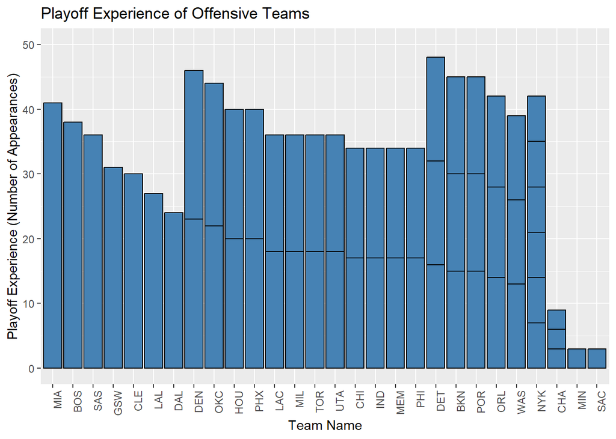

```r
ggplot(series_outcomes, aes(x = reorder(off_team, -off_team_exp), y = off_team_exp)) +
  geom_bar(stat = "identity", fill = "steelblue", color = "black") +
  ggtitle("Playoff Experience of Offensive Teams") +
  xlab("Team Name") +
  ylab("Playoff Experience (Number of Appearances)") +
  ylim(0, 50) +  # y-axis limit
  theme(axis.text.x = element_text(angle = 90, hjust = 1))
```

```r
# Installing necessary packages if not already installed
if (!require(caret)) install.packages("caret")
if (!require(dplyr)) install.packages("dplyr")
if (!require(smotefamily)) install.packages("smotefamily")
if (!require(randomForest)) install.packages("randomForest")
# Loading necessary libraries
library(caret)
library(dplyr)
library(smotefamily)
library(randomForest)



# Converting character columns to factors
series_outcomes <- series_outcomes %>%
  mutate(across(where(is.character), as.factor))

# Ensuring the target variable and season are factors
series_outcomes$series_winner <- as.factor(series_outcomes$series_winner)
series_outcomes$season <- as.factor(series_outcomes$season)

# One-Hot Encoding for the predictors, including the season
dummies <- dummyVars(" ~ .", data = series_outcomes %>% select(-series_winner, -off_team_wins, -def_team_wins))
series_outcomes_encoded <- data.frame(predict(dummies, newdata = series_outcomes))

# Adding the target and number of wins variables back to the encoded dataframe
series_outcomes_encoded$series_winner <- series_outcomes$series_winner
series_outcomes_encoded$off_team_wins <- series_outcomes$off_team_wins
series_outcomes_encoded$def_team_wins <- series_outcomes$def_team_wins

# Removing columns with zero variance
nzv <- nearZeroVar(series_outcomes_encoded)
series_outcomes_encoded <- series_outcomes_encoded[, -nzv]

# Normalizing the data (center and scale)
preProcess_params <- preProcess(series_outcomes_encoded %>% select(-series_winner, -off_team_wins, -def_team_wins), method = c("center", "scale"))
series_outcomes_scaled <- predict(preProcess_params, series_outcomes_encoded %>% select(-series_winner, -off_team_wins, -def_team_wins))

# Adding the target and number of wins variables back to the scaled dataframe
series_outcomes_scaled$series_winner <- series_outcomes_encoded$series_winner
series_outcomes_scaled$off_team_wins <- series_outcomes_encoded$off_team_wins
series_outcomes_scaled$def_team_wins <- series_outcomes_encoded$def_team_wins
```

```r
# Splitting the data into training and testing sets
set.seed(123) # For reproducibility
trainIndex <- createDataPartition(series_outcomes_scaled$series_winner, p = .8,
                                  list = FALSE,
                                  times = 1)
series_outcomes_train <- series_outcomes_scaled[trainIndex,]
series_outcomes_test  <- series_outcomes_scaled[-trainIndex,]
```

```r
# Checking class distribution
class_distribution <- table(series_outcomes_train$series_winner)
print(class_distribution)
```

```
##
## ATL BKN BOS CHI CLE DAL DEN DET GSW HOU IND LAC LAL MEM MIA MIL NOP NYK OKC ORL
##   7   4  24   4  17   9   6   8  20   7   5   8  20   4  26   7   2   2   9   5
## PHI PHX POR SAS TOR UTA WAS
##   7  13   4  20   8   6   4
```

```r
# Adjusting K to be less than the minimum class size
min_class_size <- min(class_distribution)
K <- ifelse(min_class_size > 5, 5, min_class_size - 1)

# Applying SMOTE to the training data
smote_train <- SMOTE(series_outcomes_train %>% select(-series_winner), series_outcomes_train$series_winner, K = K)
series_outcomes_train_smote <- smote_train$data
colnames(series_outcomes_train_smote)[ncol(series_outcomes_train_smote)] <- "series_winner"
series_outcomes_train_smote$series_winner <- as.factor(series_outcomes_train_smote$series_winner)

# Verifying the new class distribution after SMote
print(table(series_outcomes_train_smote$series_winner))
```

```
##
## ATL BKN BOS CHI CLE DAL DEN DET GSW HOU IND LAC LAL MEM MIA MIL NOP NYK OKC ORL
##   7   4  24   4  17   9   6   8  20   7   5   8  20   4  26   7 254   2   9   5
## PHI PHX POR SAS TOR UTA WAS
##   7  13   4  20   8   6   4
```

```r
# Random Forest model
rf_model <- randomForest(series_winner ~ ., data = series_outcomes_train_smote, ntree = 100)
rf_pred <- predict(rf_model, newdata = series_outcomes_test)

# Ensuring the levels match
rf_pred <- factor(rf_pred, levels = levels(series_outcomes_test$series_winner))

rf_confusion <- confusionMatrix(rf_pred, series_outcomes_test$series_winner)
rf_accuracy <- rf_confusion$overall['Accuracy']
print(paste("Random Forest Accuracy: ", rf_accuracy))
```

```
## [1] "Random Forest Accuracy:  0.816326530612245"
```

```r
# Linear regression for number of offensive team wins
model_off_team_wins <- lm(off_team_wins ~ ., data = series_outcomes_train_smote %>% select(-series_winner, -def_team_wins))

# Prediction on the test set
pred_off_team_wins <- predict(model_off_team_wins, newdata = series_outcomes_test %>% select(-series_winner, -off_team_wins, -def_team_wins))

# Evaluating the model
rmse_off_team_wins <- sqrt(mean((pred_off_team_wins - series_outcomes_test$off_team_wins)^2))
```

```r
# Linear regression for number of defensive team wins
model_def_team_wins <- lm(def_team_wins ~ ., data = series_outcomes_train_smote %>% select(-series_winner, -off_team_wins))

# Predict on the test set
pred_def_team_wins <- predict(model_def_team_wins, newdata = series_outcomes_test %>% select(-series_winner, -off_team_wins, -def_team_wins))

# Evaluate the model
rmse_def_team_wins <- sqrt(mean((pred_def_team_wins - series_outcomes_test$def_team_wins)^2))
print(paste("RMSE for defensive team wins: ", rmse_def_team_wins))
```

```
## [1] "RMSE for defensive team wins:  1.07944266325861"
```

This model predicts NBA playoff series outcomes, providing valuable insights for strategic decision-making.

### This Model Helps Front Office TO DO:

- **Strategic Planning**: Make informed decisions about player rotations and game strategies.
- **Resource Allocation**: Use resources more effectively based on the model’s predictions.
- **Risk Management**: Identify potential upsets and prepare accordingly.
- **Performance Insights**: Understand the strengths and weaknesses of your team and your opponents.

#### Strengths of this model:

1. **Robustness and Stability**:
   - The Random Forest algorithm, being an ensemble method, is robust to overfitting, especially with a large number of trees. It provides stable predictions even with noisy data.
2. **Feature Importance**:
   - Random Forests inherently provide feature importance metrics, which help in understanding which features are most influential in predicting the outcomes. This is crucial for model interpretability and debugging.
3. **Adaptability**:
   - This model can be easily updated with new data from future seasons. This means it stays relevant and continues to provide accurate predictions as new games are played.

#### Weaknesses

1. **Chance of Overfitting**:
   - Despite its robustness, there is still a chance of overfitting, especially if the model is too complex or if the training data is not representative of future scenarios.
2. **Ignoring Coaching Changes**:
   - The model does not account for changes in coaching strategies or adjustments made by coaches during the playoffs, which can significantly impact game outcomes.
3. **Sensitivity to Noise**:
   - While Random Forests can handle noisy data better than some other models, they are not immune to the effects of irrelevant or noisy features, which can affect prediction accuracy.

### Addressing Model Weaknesses with More Time and Data

1. **Chance of Overfitting**:
   - I will use cross-validation and hyperparameter tuning to optimize the model, and apply pruning and regularization techniques to prevent complexity.
2. **Ignoring Coaching Changes**:
   - I will integrate real-time data on coaching decisions and historical coaching performance, and collaborate with experts for qualitative insights.
3. **Sensitivity to Noise**:
   - I will implement rigorous data cleaning and robust feature engineering, and apply noise reduction techniques like PCA and regularization to minimize the impact of noisy data.

## Part 3 – Finding Insights from Your Model

Find two teams that had a competitive window of 2 or more consecutive seasons making the playoffs and that under performed your model’s expectations for them, losing series they were expected to win. Why do you think that happened? Classify one of them as bad luck and one of them as relating to a cause not currently accounted for in your model. If given more time and data, how would you use what you found to improve your model?

```r
# Load necessary library
library(dplyr)
library(tidyr)



# Filtering for Playoff Games
playoff_data <- season_team_metrics %>%
  filter(gametype == 4)

# Creating a dataframe that lists each team's appearances in the playoffs for each season
team_appearances <- playoff_data %>%
  select(season, off_team) %>%
  distinct(season, off_team)

# Self-joining to find pairs of teams in the same season
team_pairs <- team_appearances %>%
  rename(team1 = off_team) %>%
  inner_join(team_appearances, by = "season") %>%
  rename(team2 = off_team) %>%
  filter(team1 < team2)  # To avoid duplicate pairs (A, B) and (B, A)
# Identifying pairs of teams with at least two consecutive season appearances in the playoffs together
consecutive_pairs <- team_pairs %>%
  arrange(team1, team2, season) %>%
  group_by(team1, team2) %>%
  mutate(next_season = lead(season)) %>%
  filter(next_season == season + 1) %>%
  select(team1, team2, season, next_season) %>%
  distinct(team1, team2)

# Displaying the pairs of teams with consecutive appearances
consecutive_pairs
```

```
## # A tibble: 435 × 2
## # Groups:   team1, team2 [435]
##    team1 team2
##    <chr> <chr>
##  1 ATL   BKN
##  2 ATL   BOS
##  3 ATL   CHA
##  4 ATL   CHI
##  5 ATL   CLE
##  6 ATL   DAL
##  7 ATL   DEN
##  8 ATL   DET
##  9 ATL   GSW
## 10 ATL   HOU
## # ℹ 425 more rows
```

```r
series_outcomes_test$series_winner <- rf_pred
```